# Project: Gapminder World. Global metrics analysis

- Introduction
- Data Wrangling
- Exploratory Data Analysis
- Conclusions

## Introduction

> This report analyses a number of data sets that have been obtained from Gapminder World website.

> Specifically:
> > - Civil liberties.
> >   - Index of civil liberties (EIU)
> > - GDP.
> >   - Total GDP (PPP$, inflation adjusted)
> > - Children per woman.
> >   - Babies per woman (total fertility rate)

### The questions being asked of these data sets are:

> > - *Liberty*: Has liberty increased for the planet since records began? [ 1) Use statistics to calc the global mean, 2) Bucket the scores and present visually]
> > - *GDP*: Which countries have shown the most significant growth in GDP over the last 100 years
> > - *Babies per woman*: With an ever increasing global population is this down to women having more babies?

```python
# Use this cell to set up import statements for all of the packages that you
#   plan to use.

# Remember to include a 'magic word' so that your visualizations are plotted
#   inline with the notebook. See this page for more:
#   http://ipython.readthedocs.io/en/stable/interactive/magics.html

import pandas as pd
import numpy as np
import matplotlib.pyplot as plt
import seaborn as sns
%matplotlib inline
```

## Data Wrangling

```python
# Load your data and print out a few lines. Perform operations to inspect data
#   types and look for instances of missing or possibly errant data.

df_lib = pd.read_csv('data_sets/civlibx_eiu.csv', index_col='country')
df_gdp = pd.read_csv('data_sets/total_gdp_ppp_inflation_adjusted.csv', index_col='country')
df_kid = pd.read_csv('data_sets/children_per_woman_total_fertility.csv', index_col='country')
```

### General Properties

> Initially a review of the first couple of rows of data in each data set, together with the data types in each column and an assessment of whether there are any missing values

```python
df_lib.head(2)
```

| country | 2006 | 2007 | 2008 | 2009 | 2010 | 2011 | 2012 | 2013 | 2014 | 2015 | 2016 | 2017 | 2018 |
| --- | --- | --- | --- | --- | --- | --- | --- | --- | --- | --- | --- | --- | --- |
| Afghanistan | 0.441 | 0.441 | 0.441 | 0.411 | 0.382 | 0.382 | 0.382 | 0.382 | 0.382 | 0.382 | 0.382 | 0.382 | 0.382 |
| Albania | 0.706 | 0.706 | 0.706 | 0.720 | 0.735 | 0.735 | 0.735 | 0.735 | 0.735 | 0.765 | 0.765 | 0.765 | 0.765 |

```python
df_lib.info(), df_lib.shape
```

```
<class 'pandas.core.frame.DataFrame'>
Index: 164 entries, Afghanistan to Zimbabwe
Data columns (total 13 columns):
 #   Column  Non-Null Count  Dtype
---  ------  --------------  -----
 0   2006    164 non-null    float64
 1   2007    164 non-null    float64
 2   2008    164 non-null    float64
 3   2009    164 non-null    float64
 4   2010    164 non-null    float64
 5   2011    164 non-null    float64
 6   2012    164 non-null    float64
 7   2013    164 non-null    float64
 8   2014    164 non-null    float64
 9   2015    164 non-null    float64
 10  2016    164 non-null    float64
 11  2017    164 non-null    float64
 12  2018    164 non-null    float64
dtypes: float64(13)
memory usage: 17.9+ KB
```

```
(None, (164, 13))
```

```python
df_gdp.head(2)
```

| country | 1800 | 1801 | 1802 | 1803 | 1804 | 1805 | 1806 | 1807 | 1808 | 1809 | ... | 2004 | 2005 | 2006 | 2007 | 2008 | 2009 | 2010 | 2011 | 2012 | 2013 |
| --- | --- | --- | --- | --- | --- | --- | --- | --- | --- | --- | --- | --- | --- | --- | --- | --- | --- | --- | --- | --- | --- |
| Afghanistan | 2.080000e+09 | 2.080000e+09 | 2.080000e+09 | 2.080000e+09 | 2.080000e+09 | 2.080000e+09 | 2.080000e+09 | 2.080000e+09 | 2.080000e+09 | 2.080000e+09 | ... | 2.890000e+10 | 3.240000e+10 | 3.390000e+10 | 3.850000e+10 | 3.950000e+10 | 4.750000e+10 | 5.130000e+10 | 5.490000e+10 | 6.300000e+10 | 6.580000e+10 |
| Albania | 3.260000e+08 | 3.270000e+08 | 3.280000e+08 | 3.300000e+08 | 3.310000e+08 | 3.320000e+08 | 3.340000e+08 | 3.350000e+08 | 3.370000e+08 | 3.380000e+08 | ... | 2.110000e+10 | 2.230000e+10 | 2.350000e+10 | 2.490000e+10 | 2.670000e+10 | 2.760000e+10 | 2.850000e+10 | 2.930000e+10 | 3.010000e+10 | 3.070000e+10 |

2 rows × 214 columns

```python
df_gdp.info(), df_gdp.shape
```

```
<class 'pandas.core.frame.DataFrame'>
Index: 194 entries, Afghanistan to Zimbabwe
Columns: 214 entries, 1800 to 2013
dtypes: float64(214)
memory usage: 325.9+ KB
```

```
(None, (194, 214))
```

```python
df_kid.head(2)
```

| country | 1800 | 1801 | 1802 | 1803 | 1804 | 1805 | 1806 | 1807 | 1808 | 1809 | ... | 2091 | 2092 | 2093 | 2094 | 2095 | 2096 | 2097 | 2098 | 2099 | 2100 |
| --- | --- | --- | --- | --- | --- | --- | --- | --- | --- | --- | --- | --- | --- | --- | --- | --- | --- | --- | --- | --- | --- |
| Afghanistan | 7.0 | 7.0 | 7.0 | 7.0 | 7.0 | 7.0 | 7.0 | 7.0 | 7.0 | 7.0 | ... | 1.74 | 1.74 | 1.74 | 1.74 | 1.74 | 1.74 | 1.74 | 1.74 | 1.74 | 1.74 |
| Albania | 4.6 | 4.6 | 4.6 | 4.6 | 4.6 | 4.6 | 4.6 | 4.6 | 4.6 | 4.6 | ... | 1.78 | 1.78 | 1.78 | 1.79 | 1.79 | 1.79 | 1.79 | 1.79 | 1.79 | 1.79 |

2 rows × 301 columns

```python
df_kid.info(), df_kid.shape
```

```
<class 'pandas.core.frame.DataFrame'>
Index: 184 entries, Afghanistan to Zimbabwe
Columns: 301 entries, 1800 to 2100
dtypes: float64(301)
memory usage: 434.1+ KB
```

```
(None, (184, 301))
```

### Initial review of the data:

[output not shown]

### Data cleaning

At this stage no cleaning is required. When the EDA is performed futher data manipulation will be peformed to answer the questions.

## Exploratory Data Analysis

> As we have seen there are signifcant number of countries within the different data sets, I will create a sub-group of nations that will be extracted from the initial population. This will allow easier comparison and also less confusing visuals.

> NOTE: where data frames are created based on this subset of countries, the dataframe will be referenced with '_s' for *summary*.

> NOTE also: where data frames have been transposed to facilitate EDA, the dataframe will be referenced with '_t' for *transpose*.

```python
#Sub group of countries to review
"""Note that both the UK and the US are included twice (in both their long-form name and also their shortened
acronyms) as we will be abbreviating their names later."""

countries = ['Australia', 'United Kingdom', 'UK', 'US', 'United States', 'China', 'Russia', 'France', 'Germany', 'Japan']
```

### EDA: Data set 1 - Civil Liberties

```python
# For ease of viewing, I will transpose the data frame to have countries in the columns.
df_lib_t = df_lib.T
```

```python
# Removal of countries not in the summary listing, and a quick check of the output.
df_lib_ts = df_lib_t.drop(columns=[col for col in df_lib_t if col not in countries])
df_lib_ts.head(3)
```

| country | Australia | China | France | Germany | Japan | Russia | United Kingdom | United States |
| --- | --- | --- | --- | --- | --- | --- | --- | --- |
| 2006 | 1.0 | 0.118 | 0.912 | 0.941 | 0.941 | 0.559 | 0.912 | 0.853 |
| 2007 | 1.0 | 0.118 | 0.912 | 0.941 | 0.941 | 0.530 | 0.897 | 0.853 |
| 2008 | 1.0 | 0.118 | 0.912 | 0.941 | 0.941 | 0.500 | 0.882 | 0.853 |

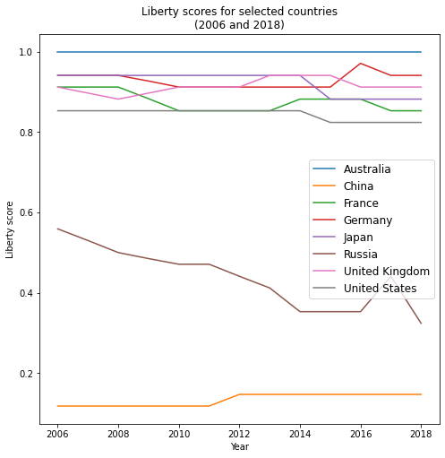

```python
#Plot the summary countries
df_lib_ts.plot(kind='line', figsize=(8,8))
plt.xlabel('Year');
plt.ylabel('Liberty score');
plt.title('Liberty scores for selected countries\n(2006 and 2018)');
plt.legend(fontsize=12);
```

#### Question:

> Is this apparent in our total population data set?

```python
# Compare summary metrics, and change in those metrics, across first period (2006) and last period (2018)

df_lib_06 = df_lib['2006'].describe()
df_lib_18 = df_lib['2018'].describe()
stats_lib = pd.DataFrame({'metrics_06': df_lib_06, 'metrics_18': df_lib_18})
stats_lib['change'] = stats_lib['metrics_18'] - stats_lib['metrics_06']
stats_lib
```

|  | metrics_06 | metrics_18 | change |
| --- | --- | --- | --- |
| count | 164.000000 | 164.000000 | 0.000000 |
| mean | 0.627713 | 0.573207 | -0.054506 |
| std | 0.280226 | 0.267888 | -0.012338 |
| min | 0.000000 | 0.000000 | 0.000000 |
| 25% | 0.382000 | 0.353000 | -0.029000 |
| 50% | 0.676000 | 0.588000 | -0.088000 |
| 75% | 0.882000 | 0.801500 | -0.080500 |
| max | 1.000000 | 1.000000 | 0.000000 |

#### Insights from the statistical analysis:

> All statistical metrics (other than maxiumum and minimum scores) show a decrease in the liberty score across the total population.

#### Further analysis required...

> Whilst the minimum score (zero) and the maximum score (one) have not changed, we do not know if there are more or less countries achieving these scores. For example: in 2006 there may have been 10 countries acheiving a maximum score of one, and in 2018 this may have reduced to just one country. The maximum score in both years is still one.

> The reduction in the mean would indicate the maximum and minimum scores demonstrate a negative movement but this would need to be confirmed (see below).

```python
# Which countries had a liberty score of 1 in 2006?

df_lib[df_lib['2006'] == 1]
```

| country | 2006 | 2007 | 2008 | 2009 | 2010 | 2011 | 2012 | 2013 | 2014 | 2015 | 2016 | 2017 | 2018 |
| --- | --- | --- | --- | --- | --- | --- | --- | --- | --- | --- | --- | --- | --- |
| Australia | 1.0 | 1.000 | 1.000 | 1.000 | 1.000 | 1.000 | 1.000 | 1.000 | 1.000 | 1.000 | 1.000 | 1.000 | 1.000 |
| Canada | 1.0 | 1.000 | 1.000 | 1.000 | 1.000 | 1.000 | 1.000 | 1.000 | 1.000 | 1.000 | 1.000 | 1.000 | 1.000 |
| Iceland | 1.0 | 0.985 | 0.971 | 0.971 | 0.971 | 0.971 | 0.971 | 0.971 | 0.971 | 0.971 | 0.971 | 0.971 | 0.971 |
| Ireland | 1.0 | 1.000 | 1.000 | 1.000 | 1.000 | 1.000 | 1.000 | 1.000 | 1.000 | 1.000 | 1.000 | 1.000 | 1.000 |
| Netherlands | 1.0 | 0.985 | 0.971 | 0.956 | 0.941 | 0.941 | 0.941 | 0.941 | 0.941 | 0.941 | 0.941 | 0.912 | 0.912 |
| New Zealand | 1.0 | 1.000 | 1.000 | 1.000 | 1.000 | 1.000 | 1.000 | 1.000 | 1.000 | 1.000 | 1.000 | 1.000 | 1.000 |
| Norway | 1.0 | 1.000 | 1.000 | 1.000 | 1.000 | 1.000 | 1.000 | 1.000 | 1.000 | 1.000 | 1.000 | 0.971 | 0.971 |
| Sweden | 1.0 | 1.000 | 1.000 | 1.000 | 1.000 | 1.000 | 1.000 | 1.000 | 1.000 | 0.971 | 0.941 | 0.941 | 0.941 |

```python
# Which countries had a liberty score of 1 in 2018?

df_lib[df_lib['2018'] == 1]
```

| country | 2006 | 2007 | 2008 | 2009 | 2010 | 2011 | 2012 | 2013 | 2014 | 2015 | 2016 | 2017 | 2018 |
| --- | --- | --- | --- | --- | --- | --- | --- | --- | --- | --- | --- | --- | --- |
| Australia | 1.0 | 1.0 | 1.0 | 1.0 | 1.0 | 1.0 | 1.0 | 1.0 | 1.0 | 1.0 | 1.0 | 1.0 | 1.0 |
| Canada | 1.0 | 1.0 | 1.0 | 1.0 | 1.0 | 1.0 | 1.0 | 1.0 | 1.0 | 1.0 | 1.0 | 1.0 | 1.0 |
| Ireland | 1.0 | 1.0 | 1.0 | 1.0 | 1.0 | 1.0 | 1.0 | 1.0 | 1.0 | 1.0 | 1.0 | 1.0 | 1.0 |
| New Zealand | 1.0 | 1.0 | 1.0 | 1.0 | 1.0 | 1.0 | 1.0 | 1.0 | 1.0 | 1.0 | 1.0 | 1.0 | 1.0 |

#### Question:

> Can further insight be obtained by presenting this visually?

#### Answer:

> If we group the countries into buckets based on their scores, and then count the number of countries in each bucket for both 2006 and 2018 this may show further evidence of a movement in civil liberties

```python
# Allow easy adjustment of the number of buckets in order to assess most user-friendly visual.

#Set a variable for the number of buckets which can then be changed for alternative analysis
buckets = 5

bin_edges = [-0.00001]
bin_names = []

# Populate the bin_edges and bin_names based on the number of buckets
for i in range(buckets):
    bin_edges.append((i+1)/buckets)
    bin_names.append(str((i)/buckets) + " - " + str((i+1)/buckets))

# Create new data columns that state which buckets the liberty score data falls into in each row
df_lib['06bucket']= pd.cut(df_lib['2006'], bin_edges, labels=bin_names)
df_lib['18bucket']= pd.cut(df_lib['2018'], bin_edges, labels=bin_names)
```

```python
# Set variables for the data to be presented visually.  In this instance value counts of each of the buckets.

bar_1 = df_lib['06bucket'].value_counts()[bin_names]
bar_2 = df_lib['18bucket'].value_counts()[bin_names]
```

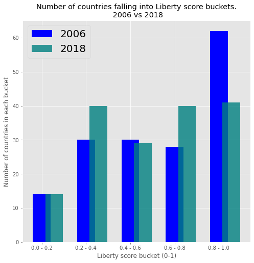

```python
# Plot the graph

plt.style.use('ggplot')
plt.figure(figsize=(8,8))
x = np.arange(buckets)
bar_width = 0.4
plt.bar(x, bar_1, width=bar_width, label='2006', color='blue' )
plt.bar(x+bar_width*0.7, bar_2, width=bar_width, label='2018', color='teal', alpha=0.8 )
plt.xlabel('Liberty score bucket (0-1)');
plt.xticks(np.arange(buckets),bin_names)
plt.ylabel('Number of countries in each bucket');
plt.title('Number of countries falling into Liberty score buckets.\n 2006 vs 2018');
plt.legend(fontsize=20);
```

#### Insight

> The most noticeable reduction for the 2006 bucket occurs in the '0.8-1.0' bucket indicating less countries achieve the highest scores. These appear to have shifted more into the lower buckets of '0.6-0.8' and '0.2-0.4'.

### EDA: Data set 2 - GDP

```python
df_gdp.head()
```

| country | 1800 | 1801 | 1802 | 1803 | 1804 | 1805 | 1806 | 1807 | 1808 | 1809 | ... | 2004 | 2005 | 2006 | 2007 | 2008 | 2009 | 2010 | 2011 | 2012 | 2013 |
| --- | --- | --- | --- | --- | --- | --- | --- | --- | --- | --- | --- | --- | --- | --- | --- | --- | --- | --- | --- | --- | --- |
| Afghanistan | 2.080000e+09 | 2.080000e+09 | 2.080000e+09 | 2.080000e+09 | 2.080000e+09 | 2.080000e+09 | 2.080000e+09 | 2.080000e+09 | 2.080000e+09 | 2.080000e+09 | ... | 2.890000e+10 | 3.240000e+10 | 3.390000e+10 | 3.850000e+10 | 3.950000e+10 | 4.750000e+10 | 5.130000e+10 | 5.490000e+10 | 6.300000e+10 | 6.580000e+10 |
| Albania | 3.260000e+08 | 3.270000e+08 | 3.280000e+08 | 3.300000e+08 | 3.310000e+08 | 3.320000e+08 | 3.340000e+08 | 3.350000e+08 | 3.370000e+08 | 3.380000e+08 | ... | 2.110000e+10 | 2.230000e+10 | 2.350000e+10 | 2.490000e+10 | 2.670000e+10 | 2.760000e+10 | 2.850000e+10 | 2.930000e+10 | 3.010000e+10 | 3.070000e+10 |
| Algeria | 3.810000e+09 | 3.820000e+09 | 3.830000e+09 | 3.850000e+09 | 3.860000e+09 | 3.870000e+09 | 3.890000e+09 | 3.900000e+09 | 3.920000e+09 | 3.930000e+09 | ... | 3.720000e+11 | 3.920000e+11 | 3.990000e+11 | 4.130000e+11 | 4.210000e+11 | 4.280000e+11 | 4.430000e+11 | 4.540000e+11 | 4.650000e+11 | 4.790000e+11 |
| Andorra | 3.340000e+06 | 3.350000e+06 | 3.360000e+06 | 3.360000e+06 | 3.370000e+06 | 3.370000e+06 | 3.380000e+06 | 3.380000e+06 | 3.390000e+06 | 3.400000e+06 | ... | 2.820000e+09 | 3.040000e+09 | 3.190000e+09 | 3.190000e+09 | 3.060000e+09 | 2.900000e+09 | 2.810000e+09 | 2.730000e+09 | NaN | NaN |
| Angola | 1.020000e+09 | 1.020000e+09 | 1.030000e+09 | 1.030000e+09 | 1.040000e+09 | 1.040000e+09 | 1.050000e+09 | 1.050000e+09 | 1.050000e+09 | 1.060000e+09 | ... | 6.310000e+10 | 7.610000e+10 | 9.020000e+10 | 1.110000e+11 | 1.270000e+11 | 1.300000e+11 | 1.340000e+11 | 1.390000e+11 | 1.460000e+11 | 1.520000e+11 |

5 rows × 214 columns

```python
# Transpose the data and then extract only the countries for our summary data set

df_gdp_t = df_gdp.T
df_gdp_ts = df_gdp_t.drop(columns=[col for col in df_gdp_t if col not in countries])
df_gdp_ts.head(2)
```

| country | Australia | China | France | Germany | Japan | Russia | United Kingdom | United States |
| --- | --- | --- | --- | --- | --- | --- | --- | --- |
| 1800 | 278000000.0 | 2.870000e+11 | 4.920000e+10 | 4.690000e+10 | NaN | 4.670000e+10 | 3.570000e+10 | 1.430000e+10 |
| 1801 | 278000000.0 | 2.890000e+11 | 4.950000e+10 | 4.740000e+10 | NaN | 4.670000e+10 | 3.620000e+10 | 1.480000e+10 |

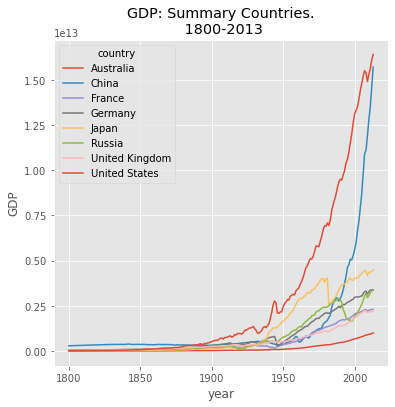

```python
# Initial view of the data

fig=6
df_gdp_ts.plot(kind='line', figsize=(fig,fig))
plt.xlabel('year')
plt.ylabel('GDP')
plt.title('GDP: Summary Countries.\n 1800-2013');
plt.show()
```

Prior to 1900 it is hard to see any difference in the data and it doesnt add much value, so lets have a look a the data since 1950.

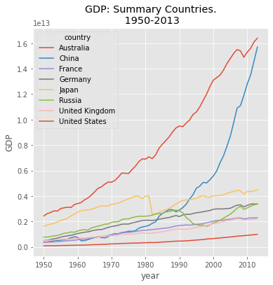

```python
# Most recent (63 years) Initial view of the data

fig=6
df_gdp_ts.loc['1950':'2013'].plot(kind='line', figsize=(fig,fig))
plt.xlabel('year')
plt.ylabel('GDP')
plt.title('GDP: Summary Countries.\n 1950-2013');
plt.show()
```

### Which countries have shown the most growth over the last 100 years? (1913 - 2013)

In order to answer this we will look at both the absolute growth in GDP and the compound annual growth rate (CAGR) over the period.

```python
# Calculate the two metrics to consider

df_gdp['CAGR'] = ((df_gdp['2013']/df_gdp['1913'])**(1/100)-1) * 100
df_gdp['Abs_gth'] = df_gdp['2013']-df_gdp['1913']
```

```python
# Summarise the listing of countries for our summary selection

df_gdp_s = df_gdp.drop(index=[ind for ind in df_gdp.index if ind not in countries])
```

```python
# Sort the data based on CAGR

df_gdp_s.sort_values(by=['CAGR'], inplace=True, ascending=False)
df_gdp_s[['1913','2013','CAGR', 'Abs_gth']]
```

| country | 1913 | 2013 | CAGR | Abs_gth |
| --- | --- | --- | --- | --- |
| China | 3.670000e+11 | 1.570000e+13 | 3.827485 | 1.533300e+13 |
| Australia | 3.970000e+10 | 9.940000e+11 | 3.272802 | 9.543000e+11 |
| Japan | 1.920000e+11 | 4.480000e+12 | 3.200017 | 4.288000e+12 |
| United States | 8.370000e+11 | 1.640000e+13 | 3.019914 | 1.556300e+13 |
| Russia | 2.760000e+11 | 3.360000e+12 | 2.530790 | 3.084000e+12 |
| France | 2.610000e+11 | 2.300000e+12 | 2.199995 | 2.039000e+12 |
| Germany | 4.500000e+11 | 3.380000e+12 | 2.036850 | 2.930000e+12 |
| United Kingdom | 3.150000e+11 | 2.220000e+12 | 1.971880 | 1.905000e+12 |

```python
# Sort the data based on Absolute growth

df_gdp_s.sort_values(by=['Abs_gth'], inplace=True, ascending=False)
df_gdp_s[['1913','2013','CAGR', 'Abs_gth']]
```

| country | 1913 | 2013 | CAGR | Abs_gth |
| --- | --- | --- | --- | --- |
| United States | 8.370000e+11 | 1.640000e+13 | 3.019914 | 1.556300e+13 |
| China | 3.670000e+11 | 1.570000e+13 | 3.827485 | 1.533300e+13 |
| Japan | 1.920000e+11 | 4.480000e+12 | 3.200017 | 4.288000e+12 |
| Russia | 2.760000e+11 | 3.360000e+12 | 2.530790 | 3.084000e+12 |
| Germany | 4.500000e+11 | 3.380000e+12 | 2.036850 | 2.930000e+12 |
| France | 2.610000e+11 | 2.300000e+12 | 2.199995 | 2.039000e+12 |
| United Kingdom | 3.150000e+11 | 2.220000e+12 | 1.971880 | 1.905000e+12 |
| Australia | 3.970000e+10 | 9.940000e+11 | 3.272802 | 9.543000e+11 |

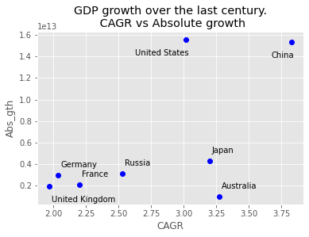

```python
# Plot the data points on a scatter graph for visual assessment

x1 = df_gdp_s['CAGR']
x2 = df_gdp_s['Abs_gth']
plt.plot(x1, x2, 'o', color='blue');
plt.xlabel('CAGR')
plt.ylabel('Abs_gth')
for x,y,z in zip(list(x1),list(x2),list(df_gdp_s.index)):
    if z in ['Germany', 'France', 'Australia', 'Russia', 'Japan']:
        plt.annotate(z, (x,y), textcoords="offset points", xytext=(3,10), ha='left')
    elif z in ['United Kingdom']:
        plt.annotate(z, (x,y), textcoords="offset points", xytext=(3,-20), ha='left')
    else:
        plt.annotate(z, (x,y), textcoords="offset points", xytext=(3,-20), ha='right')
plt.title('GDP growth over the last century.\n CAGR vs Absolute growth');
```

Whilst China and the US clearly stand out from the rest of our selected countries, it is interesting to note that both Japan and Australia have demonstrated higher CAGR than the US, however starting from a low base. The European countries of France, Germany and the UK have lagged behind in terms of CAGR over the period in question.

```python
# See how the top 3 CAGR's for the total population compare to our selection of countries.

df_gdp.sort_values(by=['CAGR'], inplace=True, ascending=False)
df_gdp[['1913','2013','CAGR', 'Abs_gth']].head(3)
```

| country | 1913 | 2013 | CAGR | Abs_gth |
| --- | --- | --- | --- | --- |
| Qatar | 27500000.0 | 2.550000e+11 | 9.565058 | 2.549725e+11 |
| United Arab Emirates | 132000000.0 | 4.770000e+11 | 8.537408 | 4.768680e+11 |
| Kuwait | 236000000.0 | 2.470000e+11 | 7.200756 | 2.467640e+11 |

Insight:

> Whilst China, Australia and Japan have the highest growth rates of our selected countries, they are noticeably below the growth rates of the middle eastern oil states of Qatar, the UAE and Kuwait.

### EDA: Data set 3 - Population

```python
# Review metrics at the turn of each of the centuries included within the data set.

df_kid[['1800','1900','2000','2100']].describe()
```

|  | 1800 | 1900 | 2000 | 2100 |
| --- | --- | --- | --- | --- |
| count | 184.000000 | 184.000000 | 184.000000 | 184.000000 |
| mean | 6.110707 | 5.905978 | 3.352391 | 1.873478 |
| std | 0.791456 | 1.022217 | 1.777817 | 0.153074 |
| min | 4.040000 | 2.800000 | 1.120000 | 1.450000 |
| 25% | 5.670000 | 5.347500 | 1.807500 | 1.780000 |
| 50% | 6.190000 | 6.105000 | 2.840000 | 1.810000 |
| 75% | 6.717500 | 6.675000 | 4.550000 | 1.910000 |
| max | 8.100000 | 8.050000 | 7.680000 | 2.460000 |

Whilst the mean and numerous other metrics shows a clear downward trend the maximum does for the historic metrics however does then follow in the forecast out to 2100.

```python
# Transpose the data, and check for output to review

df_kid_t = df_kid.T
df_kid_t.head(2)
```

| country | Afghanistan | Albania | Algeria | Angola | Antigua and Barbuda | Argentina | Armenia | Australia | Austria | Azerbaijan | ... | United Kingdom | United States | Uruguay | Uzbekistan | Vanuatu | Venezuela | Vietnam | Yemen | Zambia | Zimbabwe |
| --- | --- | --- | --- | --- | --- | --- | --- | --- | --- | --- | --- | --- | --- | --- | --- | --- | --- | --- | --- | --- | --- |
| 1800 | 7.0 | 4.6 | 6.99 | 6.93 | 5.0 | 6.8 | 7.8 | 6.50 | 5.1 | 8.1 | ... | 4.97 | 7.03 | 5.97 | 5.71 | 6.6 | 5.63 | 4.7 | 6.88 | 6.71 | 6.75 |
| 1801 | 7.0 | 4.6 | 6.99 | 6.93 | 5.0 | 6.8 | 7.8 | 6.48 | 5.1 | 8.1 | ... | 4.60 | 7.01 | 5.97 | 5.71 | 6.6 | 5.63 | 4.7 | 6.88 | 6.71 | 6.75 |

2 rows × 184 columns

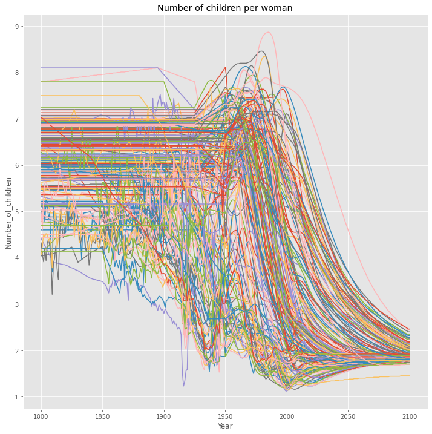

```python
# Plot the data to gain an initial impression and assess if any global/macro trends are apparent. r
# Removal of the label due to number of countries present in the data set.

df_kid_t.plot(kind='line', figsize=(12,12), legend=None)
plt.title("Number of children per woman")
plt.ylabel("Number_of_children")
plt.xlabel("Year")
```

Wow - very messy but a number of insights still stand out:

```
- The forecasted children per women across all countries appear to be converging to approximately 2, despite significant variation in the historic actuals.
- A number of countries appear to not have any data prior to circa 1930 - up until which point the metrics are cinsistenyl flat (horizontal).  This would need to be investigated / confirmed.
- The macro trend appears to be a consistent on going reduction in the metric starting with an average of approx 6 in 1800 leading to an average of circa 2.5 in 2050.
- Numbers appeared to sink signifcantly for a number of countries around 1930/1940 (coincidentally the time of World War 2), but then increase again around 1950, and then fall again around 1980.
```

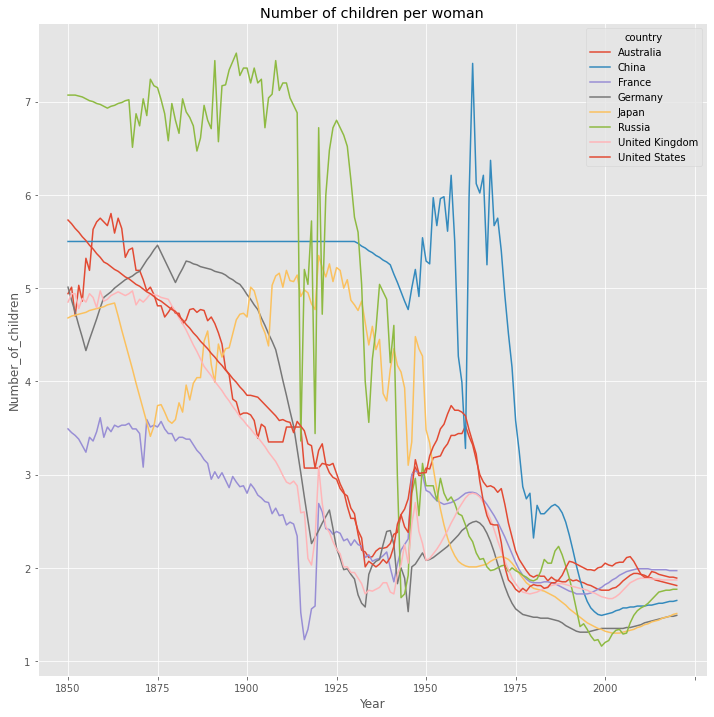

```python
# Next plot the summary data, which should prove easier to assess for specific countries.

countries = ['Australia', 'United Kingdom', 'United States', 'UK', 'US', 'China', 'Russia', 'France', 'Germany', 'Japan']
df_kid_ts = df_kid_t.drop(columns=[col for col in df_kid_t if col not in countries])
df_kid_ts.loc['1850':'2020',:].plot(kind='line', figsize=(12,12))
plt.title("Number of children per woman")
plt.ylabel("Number_of_children")
plt.xlabel("Year")
```

Whilst this is easier to read the movements are still quite hard to read due to continual annual movements up and down.

I will now present a moving average which should seek to smooth this data and make it easier to read.

```python
#Rename the Uk column header so that it doesnt conflict with the US column in the next step where they are renamed
df_kid_ts = df_kid_ts.rename(columns = {'United Kingdom': 'UK', 'United States': 'US'})
```

```python
# Calculate the rolling averages and drop the first 9 rows with Nans

yrs = 10
for c in df_kid_ts.columns:
    df_kid_ts[c[0:2] + '_MA' + str(yrs)] = df_kid_ts[c].rolling(yrs).mean()
df_kid_ts.drop(df_kid_ts.index[0:yrs-1], inplace=True, axis=0)
df_kid_ts.head(15)
```

| country | Australia | China | France | Germany | Japan | Russia | UK | US | Au_MA10 | Ch_MA10 | Fr_MA10 | Ge_MA10 | Ja_MA10 | Ru_MA10 | UK_MA10 | US_MA10 |
| --- | --- | --- | --- | --- | --- | --- | --- | --- | --- | --- | --- | --- | --- | --- | --- | --- |
| 1809 | 6.32 | 5.5 | 3.95 | 5.36 | 4.34 | 7.0 | 5.24 | 6.83 | 6.41 | 5.5 | 4.181 | 5.380 | 4.211 | 7.0 | 5.326 | 6.930 |
| 1810 | 6.30 | 5.5 | 3.90 | 5.35 | 4.37 | 7.0 | 5.36 | 6.81 | 6.39 | 5.5 | 4.130 | 5.375 | 4.240 | 7.0 | 5.365 | 6.908 |
| 1811 | 6.28 | 5.5 | 3.89 | 5.35 | 4.40 | 7.0 | 5.43 | 6.79 | 6.37 | 5.5 | 4.083 | 5.370 | 4.269 | 7.0 | 5.448 | 6.886 |
| 1812 | 6.26 | 5.5 | 3.89 | 5.34 | 4.43 | 7.0 | 5.31 | 6.76 | 6.35 | 5.5 | 4.041 | 5.365 | 4.298 | 7.0 | 5.449 | 6.863 |
| 1813 | 6.24 | 5.5 | 3.88 | 5.34 | 4.43 | 7.0 | 5.45 | 6.74 | 6.33 | 5.5 | 4.003 | 5.360 | 4.324 | 7.0 | 5.433 | 6.841 |
| 1814 | 6.22 | 5.5 | 3.88 | 5.33 | 4.44 | 7.0 | 5.46 | 6.72 | 6.31 | 5.5 | 3.970 | 5.355 | 4.348 | 7.0 | 5.414 | 6.819 |
| 1815 | 6.20 | 5.5 | 3.87 | 5.33 | 4.44 | 7.0 | 6.02 | 6.70 | 6.29 | 5.5 | 3.941 | 5.350 | 4.369 | 7.0 | 5.461 | 6.797 |
| 1816 | 6.18 | 5.5 | 3.86 | 5.32 | 4.45 | 7.0 | 5.73 | 6.67 | 6.27 | 5.5 | 3.917 | 5.345 | 4.389 | 7.0 | 5.485 | 6.774 |
| 1817 | 6.16 | 5.5 | 3.86 | 5.32 | 4.45 | 7.0 | 5.69 | 6.65 | 6.25 | 5.5 | 3.898 | 5.340 | 4.406 | 7.0 | 5.509 | 6.752 |
| 1818 | 6.14 | 5.5 | 3.85 | 5.33 | 4.45 | 7.0 | 5.54 | 6.63 | 6.23 | 5.5 | 3.883 | 5.337 | 4.420 | 7.0 | 5.523 | 6.730 |
| 1819 | 6.12 | 5.5 | 3.85 | 5.35 | 4.46 | 7.0 | 5.45 | 6.61 | 6.21 | 5.5 | 3.873 | 5.336 | 4.432 | 7.0 | 5.544 | 6.708 |
| 1820 | 6.10 | 5.5 | 3.84 | 5.37 | 4.46 | 7.0 | 5.40 | 6.59 | 6.19 | 5.5 | 3.867 | 5.338 | 4.441 | 7.0 | 5.548 | 6.686 |
| 1821 | 6.08 | 5.5 | 3.83 | 5.35 | 4.47 | 7.0 | 5.55 | 6.57 | 6.17 | 5.5 | 3.861 | 5.338 | 4.448 | 7.0 | 5.560 | 6.664 |
| 1822 | 6.06 | 5.5 | 3.82 | 5.33 | 4.47 | 7.0 | 5.69 | 6.54 | 6.15 | 5.5 | 3.854 | 5.337 | 4.452 | 7.0 | 5.598 | 6.642 |
| 1823 | 6.04 | 5.5 | 3.80 | 5.31 | 4.48 | 7.0 | 5.54 | 6.52 | 6.13 | 5.5 | 3.846 | 5.334 | 4.457 | 7.0 | 5.607 | 6.620 |

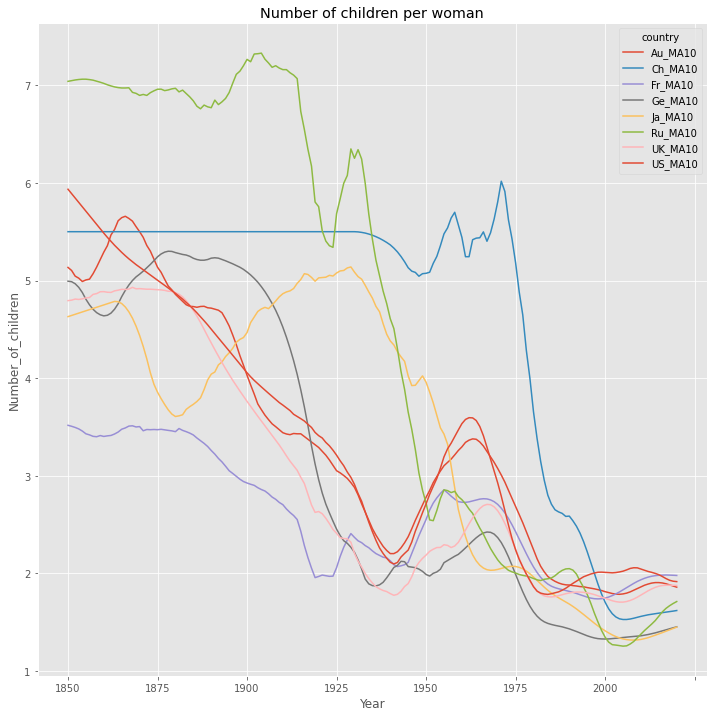

```python
# Drop the yearly data so we are left with just the moving averages, and filter on years to remove the forecast.

df_kid_tsm = df_kid_ts.drop(columns=[col for col in df_kid_ts if col in countries])
df_kid_tsm.loc['1850':'2020',:].plot(kind='line', figsize=(12,12))
plt.title("Number of children per woman")
plt.ylabel("Number_of_children")
plt.xlabel("Year")
```

Much nicer.

But how does this selection of countries compare to our total population from earlier?

Lets compute some averages for the two sets and compare them.

```python
# Calculate the averages for our selection of moving averages

df_kid_tsm['sel_MA10'] = df_kid_tsm.mean(axis=1)
```

```python
# Calculate the averages for our original total population

years = 10
df_kid_t['pop_avg'] = df_kid_t.mean(axis=1)
df_kid_t['pop_MA10'] = df_kid_t['pop_avg'].rolling(yrs).mean()
```

```python
# Add on the new column to our existing dataset

df_kid_tsm = df_kid_tsm.assign(pop_MA10=df_kid_t['pop_MA10'])
```

```python
# And check...

df_kid_tsm.head(2)
```

| country | Au_MA10 | Ch_MA10 | Fr_MA10 | Ge_MA10 | Ja_MA10 | Ru_MA10 | UK_MA10 | US_MA10 | sel_MA10 | pop_MA10 |
| --- | --- | --- | --- | --- | --- | --- | --- | --- | --- | --- |
| 1809 | 6.41 | 5.5 | 4.181 | 5.380 | 4.211 | 7.0 | 5.326 | 6.930 | 5.61725 | 6.105125 |
| 1810 | 6.39 | 5.5 | 4.130 | 5.375 | 4.240 | 7.0 | 5.365 | 6.908 | 5.61350 | 6.104043 |

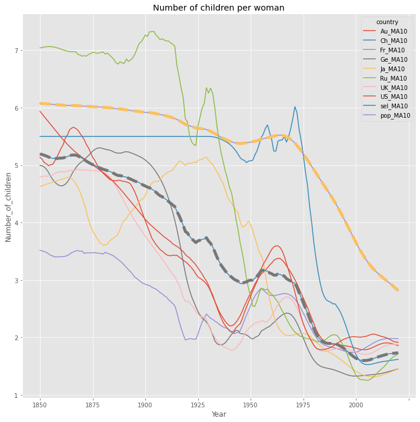

```python
# And plot...

from1 = str(1850)
to1 = str(2020)

df_kid_tsm.loc[from1:to1,:].plot(kind='line', figsize=(12,12))

xx1 = df_kid_tsm.loc[from1:to1,:].index
yy1 = list(df_kid_tsm['sel_MA10'].loc[from1:to1])
zz1 = list(df_kid_tsm['pop_MA10'].loc[from1:to1])

plt.title("Number of children per woman")
plt.ylabel("Number_of_children")
plt.xlabel("Year")
plt.plot(xx1,yy1,label = 'AVG_MA10', lw=5, ls='--')
plt.plot(xx1,zz1,label = 'AVG_MA10', lw=5, ls='--')
plt.show()
```

Clearly our selected countries (large developed nations) appear to be ahead of the broader global population, which includes a number of African, Asian and South American countries. Note though that our metrics and analysis have not been weighted for population. Each country has the same influence on the mertrics whereas in reality China and India (two of the most popularted countries) would have a much greater signifcance than smaller countries like Luxembourg.

## Conclusions

> **Tip**: Finally, summarize your findings and the results that have been performed. Make sure that you are clear with regards to the limitations of your exploration. If you haven't done any statistical tests, do not imply any statistical conclusions. And make sure you avoid implying causation from correlation!

> **Tip**: Once you are satisfied with your work, you should save a copy of the report in HTML or PDF form via the **File** > **Download as** submenu. Before exporting your report, check over it to make sure that the flow of the report is complete. You should probably remove all of the "Tip" quotes like this one so that the presentation is as tidy as possible. Congratulations!

### *Liberty*: Has liberty increased for the planet since records began?

> Broadly speaking liberty has not improved over the period under review from these data sets.

> The mean liberty score has decreased from 0.63 in 2006 to 0.57 in 2018.

> This appears to have been driven by the highest scoring countries at the start of the period achieving lower scores by the end of the period, together with other countries slipping down the scoring.

### *GDP*: Which countries have shown the most significant growth in GDP over the last 100 years

> Across the total population of countries included in our data set the highest growth countries were: Qatar, UAE, and Kuwait.

> In our selected large developed economies, we could see that China, Australia and Japan were the largest growth countries.

### *Babies per woman*: With an ever increasing global population is this down to women having more babies?

> In summary: No. Across all countries it appears woman are having less children, with a noticeable decline occuring over the last 100 years.

> This appears to be led by the developed nations, based on our analysis, as their fertility rates are decreasing earlier than the less developed nations however this would need to be confirmed with further analysis.